# qPCR Experiment

# Installation

```r
if(!require(qPCRExperiment)){
    BiocManager::install('NormqPCR')
    devtools::install_github('tjgorrie/miRoar')
}
library(qPCRExperiment)
```

# Data Import

Importing data into R using the `qPCRExperiment` is very easy.

```r
input_directory <- system.file('extdata', 'edsfiles', package='qPCRExperiment')
example_experiment <- readEDSExperiment(input_directory, directory=TRUE, verbose=FALSE)
# As this example data contains two experiments with differing number of detectors we need to run
# the following steps, it is unlikely you would need to do this if you aren't mixing experiments as we are.
# Filter data to detectors present in all samples (in this case 6)
shared_detectors <- names(which(table(unlist(sapply(example_experiment[['plates']], detector_names))) == 6))
example_experiment <- example_experiment[shared_detectors,,]
print(example_experiment)
```

```
## EDS Experiment with:
##   2 Plates
##   6 Samples
##   551 Detectors
## History:
##             Submitted            Finished
## 1 2023-12-29 15:16:13 2023-12-29 15:16:35
## 2 2023-12-29 15:16:35 2023-12-29 15:16:36
##                                                        Comment
## 1 Create EDSExperiment with 2 plates, 6 samples, 754 detectors
## 2                 Subset to 2 plates, 6 samples, 551 detectors
```

# The `Experiment` Object

The `Experiment` object attempts to collect together all the infomation from multiple EDS files. From the top-level down, the experiment contains a list of `Plate`s which are each individual EDS file that goes into making the `Experiment` object. Within each `Plate` there are a list of `Well`s that contains the actual information from the experiment. The data is organised in such a way that you should only ever need to interact with the `Experiment` and can manipulate the data as needed without ever changing the values inside the `Well`s

# Basic Processing

Experiment objects can be filtered using `[` methods to manipulate the number of samples, detectors or plates that we wish to analyse.

```r
example_experiment[detector_names,sample_names,plate_names]
```

```r
head(detector_names(example_experiment))
```

```
## [1] "hsa-miR-409-5p_478872_mir" "hsa-miR-424-5p_478092_mir"
## [3] "hsa-miR-30b-5p_478007_mir" "hsa-miR-29a-3p_478587_mir"
## [5] "hsa-miR-485-3p_478125_mir" "hsa-miR-484_478308_mir"
```

```r
example_experiment[c("hsa-miR-937-3p_479212_mir", "hsa-miR-938_479214_mir", "hsa-miR-939-5p_478245_mir"),,]
```

```
## EDS Experiment with:
##   2 Plates
##   6 Samples
##   3 Detectors
## History:
##             Submitted            Finished
## 1 2023-12-29 15:16:13 2023-12-29 15:16:35
## 2 2023-12-29 15:16:35 2023-12-29 15:16:36
## 3 2023-12-29 15:16:36 2023-12-29 15:16:36
##                                                        Comment
## 1 Create EDSExperiment with 2 plates, 6 samples, 754 detectors
## 2                 Subset to 2 plates, 6 samples, 551 detectors
## 3                   Subset to 2 plates, 6 samples, 3 detectors
```

```r
sample_names(example_experiment)
```

```
## [1] "KCL-010-14-1" "SALIVA-A"     "SALIVA-B"     "UCLA-4823-8"  "UCLA-5072-8"
## [6] "UCLA-4604-8"
```

```r
example_experiment[,c("SALIVA-A", "SALIVA-B"),]
```

```
## EDS Experiment with:
##   2 Plates
##   2 Samples
##   551 Detectors
## History:
##             Submitted            Finished
## 1 2023-12-29 15:16:13 2023-12-29 15:16:35
## 2 2023-12-29 15:16:35 2023-12-29 15:16:36
## 3 2023-12-29 15:16:36 2023-12-29 15:16:36
##                                                        Comment
## 1 Create EDSExperiment with 2 plates, 6 samples, 754 detectors
## 2                 Subset to 2 plates, 6 samples, 551 detectors
## 3                 Subset to 2 plates, 2 samples, 551 detectors
```

```r
plate_names(example_experiment)
```

```
##    /private/var/folders/pj/x9ry1wc12t780w6ql1c219kr0000gn/T/RtmpZiJdrF/temp_libpath1126420833904/qPCRExperiment/extdata/edsfiles/BPR14-13-01-19.eds
##                                                                                                                                             "BPR14"
## /private/var/folders/pj/x9ry1wc12t780w6ql1c219kr0000gn/T/RtmpZiJdrF/temp_libpath1126420833904/qPCRExperiment/extdata/edsfiles/newBXF34-28-01-19.eds
##                                                                                                                                             "BXF34"
```

```r
example_experiment[,,c("BXF34")]
```

```
## EDS Experiment with:
##   1 Plates
##   3 Samples
##   551 Detectors
## History:
##             Submitted            Finished
## 1 2023-12-29 15:16:13 2023-12-29 15:16:35
## 2 2023-12-29 15:16:35 2023-12-29 15:16:36
## 3 2023-12-29 15:16:36 2023-12-29 15:16:36
##                                                        Comment
## 1 Create EDSExperiment with 2 plates, 6 samples, 754 detectors
## 2                 Subset to 2 plates, 6 samples, 551 detectors
## 3                 Subset to 1 plates, 3 samples, 551 detectors
```

# Examplar Quality Control

The `Experiment` object contains a couple of varieties cycle threshold values, Namely `Ct` and `Crt Raw`. These can be accessed via the `get` method:

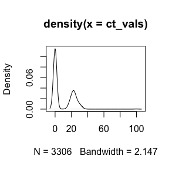

```r
# The `deep=TRUE` argument lets the experiment object see data into the wells.
ct_vals <- example_experiment$get('Avg Ct', deep=TRUE)
plot(density(ct_vals))
```

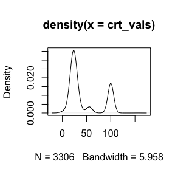

```r
crt_vals <- example_experiment$get('Crt Raw', deep=TRUE)
plot(density(crt_vals))
```

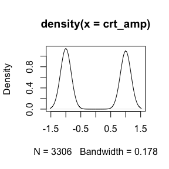

```r
crt_amp <- example_experiment$get('Crt Amp', deep=TRUE)
plot(density(crt_amp))
```

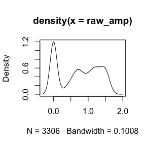

```r
raw_amp <- example_experiment$get('Raw Amp Score', deep=TRUE)
plot(density(raw_amp))
```

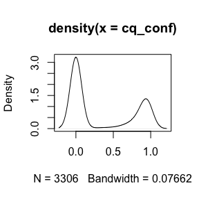

```r
cq_conf <- example_experiment$get('Cq Conf', deep=TRUE)
plot(density(cq_conf))
```

For our analysis in xyz paper, we used a min `Cq Conf` of 0.8, A min `Crt Amp` of 0 and also limited our analyses to 0 and 40. Seeing as we extracted the raw data we can simply apply the filters to the objects in memory.

```r
crt_vals_filtered <- crt_vals
is.na(crt_vals_filtered) <- cq_conf < 0.8 | crt_amp < 0 | crt_vals <= 0 | crt_vals >= 40
dim(na.omit(crt_vals))
```

```
## [1] 551   6
```

```r
dim(na.omit(crt_vals_filtered))
```

```
## [1] 42  6
```

# Calculating dCT Values

We provide a fancy method

```r
# Use global median to calculate dCt Values
global_dct <- deltaCt(crt_vals_filtered, method="global")

# Pick 1 or more HKs to use as factors (uses geometric mean of selected HKs)
endogenous_dct <- deltaCt(crt_vals_filtered, method="endogenous", HKs=c("hsa-miR-598-3p_478172_mir"))

# Perform geNorm method and use 10 HKs
genorm_dct <- deltaCt(crt_vals_filtered, method="geNorm", HKs=10)
```

```
## ###############################################################
```

```
## Step 1:
```

```
## stability values M:
```

```
##  hsa-miR-425-5p_478094_mir   hsa-let-7g-5p_478580_mir
##                   1.731611                   1.742212
##  hsa-miR-29a-3p_478587_mir   hsa-miR-22-5p_477987_mir
##                   1.746730                   1.747217
##   hsa-let-7b-5p_478576_mir  hsa-miR-423-3p_478327_mir
##                   1.768723                   1.781721
##  hsa-miR-191-5p_477952_mir  hsa-miR-324-5p_478024_mir
##                   1.782464                   1.804198
## hsa-miR-500a-3p_478951_mir hsa-miR-374b-5p_478389_mir
##                   1.836505                   1.845627
##  hsa-miR-455-3p_478112_mir  hsa-miR-503-5p_478143_mir
##                   1.877758                   1.884586
##   hsa-miR-17-5p_478447_mir  hsa-miR-598-3p_478172_mir
##                   1.912882                   1.924156
##  hsa-miR-455-5p_478113_mir  hsa-miR-660-5p_478192_mir
##                   1.933747                   2.002488
##  hsa-miR-652-3p_478189_mir hsa-miR-190a-5p_478358_mir
##                   2.077085                   2.087443
##  hsa-miR-186-5p_477940_mir  hsa-miR-26a-5p_477995_mir
##                   2.097956                   2.149056
##  hsa-miR-338-5p_478038_mir hsa-miR-151a-3p_477919_mir
##                   2.158312                   2.240776
##  hsa-miR-222-3p_477982_mir  hsa-miR-221-3p_477981_mir
##                   2.265286                   2.311655
## hsa-miR-106b-3p_477866_mir  hsa-miR-185-5p_477939_mir
##                   2.330742                   2.354083
##   hsa-miR-21-5p_477975_mir hsa-miR-193b-3p_478314_mir
##                   2.477150                   2.478757
##   hsa-miR-93-5p_478210_mir  hsa-miR-143-3p_477912_mir
##                   2.517073                   2.679016
##  hsa-miR-338-3p_478037_mir  hsa-miR-29b-3p_478369_mir
##                   2.722317                   2.762770
##  hsa-miR-424-3p_478091_mir hsa-miR-181a-5p_477857_mir
##                   2.781357                   2.873947
## hsa-miR-548d-5p_480870_mir  hsa-miR-361-3p_478055_mir
##                   2.904725                   2.928279
## hsa-miR-181b-5p_478583_mir  hsa-miR-128-3p_477892_mir
##                   3.209711                   3.384220
##  hsa-miR-210-3p_477970_mir hsa-miR-125b-5p_477885_mir
##                   3.406297                   3.807756
##  hsa-miR-342-3p_478043_mir hsa-miR-181c-5p_477934_mir
##                   3.880758                   4.571272
```

```
## average stability M: 2.39953388968525
```

```
## variable with lowest stability (largest M value):    hsa-miR-181c-5p_477934_mir
```

```
## Pairwise variation, (41/42): 0.105769588238506
```

```
## ###############################################################
```

```
## Step 2:
```

```
## stability values M:
```

```
##   hsa-let-7g-5p_478580_mir  hsa-miR-425-5p_478094_mir
##                   1.659817                   1.662810
##  hsa-miR-29a-3p_478587_mir   hsa-miR-22-5p_477987_mir
##                   1.666166                   1.682637
##   hsa-let-7b-5p_478576_mir  hsa-miR-423-3p_478327_mir
##                   1.687194                   1.708776
##  hsa-miR-191-5p_477952_mir  hsa-miR-324-5p_478024_mir
##                   1.722399                   1.745602
## hsa-miR-500a-3p_478951_mir hsa-miR-374b-5p_478389_mir
##                   1.761726                   1.780034
##  hsa-miR-455-3p_478112_mir  hsa-miR-503-5p_478143_mir
##                   1.808635                   1.822173
##   hsa-miR-17-5p_478447_mir  hsa-miR-455-5p_478113_mir
##                   1.827649                   1.842857
##  hsa-miR-598-3p_478172_mir  hsa-miR-660-5p_478192_mir
##                   1.868905                   1.919447
##  hsa-miR-652-3p_478189_mir hsa-miR-190a-5p_478358_mir
##                   1.983368                   2.008960
##  hsa-miR-26a-5p_477995_mir  hsa-miR-186-5p_477940_mir
##                   2.056045                   2.067922
##  hsa-miR-338-5p_478038_mir hsa-miR-151a-3p_477919_mir
##                   2.101359                   2.214503
##  hsa-miR-221-3p_477981_mir  hsa-miR-222-3p_477982_mir
##                   2.215316                   2.220799
## hsa-miR-106b-3p_477866_mir  hsa-miR-185-5p_477939_mir
##                   2.239744                   2.341563
##   hsa-miR-21-5p_477975_mir hsa-miR-193b-3p_478314_mir
##                   2.379277                   2.384154
##   hsa-miR-93-5p_478210_mir  hsa-miR-143-3p_477912_mir
##                   2.426915                   2.594024
##  hsa-miR-424-3p_478091_mir  hsa-miR-338-3p_478037_mir
##                   2.684324                   2.708772
##  hsa-miR-29b-3p_478369_mir hsa-miR-548d-5p_480870_mir
##                   2.745415                   2.806498
## hsa-miR-181a-5p_477857_mir  hsa-miR-361-3p_478055_mir
##                   2.893585                   2.927009
## hsa-miR-181b-5p_478583_mir  hsa-miR-210-3p_477970_mir
##                   3.247275                   3.309703
##  hsa-miR-128-3p_477892_mir hsa-miR-125b-5p_477885_mir
##                   3.417942                   3.841042
##  hsa-miR-342-3p_478043_mir
##                   3.946486
```

```
## average stability M: 2.29094698833371
```

```
## variable with lowest stability (largest M value):    hsa-miR-342-3p_478043_mir
```

```
## Pairwise variation, (40/41): 0.0923362585110272
```

```
## ###############################################################
```

```
## Step 3:
```

```
## stability values M:
```

```
##   hsa-let-7g-5p_478580_mir  hsa-miR-29a-3p_478587_mir
##                   1.592513                   1.601143
##  hsa-miR-425-5p_478094_mir   hsa-let-7b-5p_478576_mir
##                   1.609868                   1.619785
##   hsa-miR-22-5p_477987_mir  hsa-miR-423-3p_478327_mir
##                   1.635046                   1.651793
##  hsa-miR-191-5p_477952_mir hsa-miR-500a-3p_478951_mir
##                   1.678694                   1.702185
##  hsa-miR-324-5p_478024_mir hsa-miR-374b-5p_478389_mir
##                   1.705019                   1.727727
##   hsa-miR-17-5p_478447_mir  hsa-miR-455-3p_478112_mir
##                   1.754594                   1.758192
##  hsa-miR-455-5p_478113_mir  hsa-miR-503-5p_478143_mir
##                   1.767838                   1.776068
##  hsa-miR-598-3p_478172_mir  hsa-miR-660-5p_478192_mir
##                   1.831438                   1.853266
##  hsa-miR-652-3p_478189_mir hsa-miR-190a-5p_478358_mir
##                   1.904686                   1.944230
##  hsa-miR-26a-5p_477995_mir  hsa-miR-338-5p_478038_mir
##                   1.976407                   2.053376
##  hsa-miR-186-5p_477940_mir  hsa-miR-221-3p_477981_mir
##                   2.053978                   2.133973
## hsa-miR-106b-3p_477866_mir hsa-miR-151a-3p_477919_mir
##                   2.161818                   2.198883
##  hsa-miR-222-3p_477982_mir   hsa-miR-21-5p_477975_mir
##                   2.199634                   2.294382
## hsa-miR-193b-3p_478314_mir   hsa-miR-93-5p_478210_mir
##                   2.302105                   2.347589
##  hsa-miR-185-5p_477939_mir  hsa-miR-143-3p_477912_mir
##                   2.349584                   2.526837
##  hsa-miR-424-3p_478091_mir  hsa-miR-338-3p_478037_mir
##                   2.604636                   2.700925
## hsa-miR-548d-5p_480870_mir  hsa-miR-29b-3p_478369_mir
##                   2.722402                   2.748570
## hsa-miR-181a-5p_477857_mir  hsa-miR-361-3p_478055_mir
##                   2.927817                   2.941505
##  hsa-miR-210-3p_477970_mir hsa-miR-181b-5p_478583_mir
##                   3.225136                   3.295669
##  hsa-miR-128-3p_477892_mir hsa-miR-125b-5p_477885_mir
##                   3.475922                   3.886670
```

```
## average stability M: 2.2060475474383
```

```
## variable with lowest stability (largest M value):    hsa-miR-125b-5p_477885_mir
```

```
## Pairwise variation, (39/40): 0.093441487693936
```

```
## ###############################################################
```

```
## Step 4:
```

```
## stability values M:
```

```
##   hsa-let-7g-5p_478580_mir  hsa-miR-29a-3p_478587_mir
##                   1.526785                   1.537955
##  hsa-miR-425-5p_478094_mir   hsa-let-7b-5p_478576_mir
##                   1.553087                   1.557401
##   hsa-miR-22-5p_477987_mir  hsa-miR-423-3p_478327_mir
##                   1.584914                   1.602486
##  hsa-miR-191-5p_477952_mir hsa-miR-500a-3p_478951_mir
##                   1.636632                   1.637329
##  hsa-miR-324-5p_478024_mir hsa-miR-374b-5p_478389_mir
##                   1.665753                   1.680836
##   hsa-miR-17-5p_478447_mir  hsa-miR-455-5p_478113_mir
##                   1.684183                   1.694575
##  hsa-miR-455-3p_478112_mir  hsa-miR-503-5p_478143_mir
##                   1.713581                   1.729748
##  hsa-miR-660-5p_478192_mir  hsa-miR-598-3p_478172_mir
##                   1.783314                   1.803982
##  hsa-miR-652-3p_478189_mir hsa-miR-190a-5p_478358_mir
##                   1.826987                   1.870350
##  hsa-miR-26a-5p_477995_mir  hsa-miR-338-5p_478038_mir
##                   1.903048                   2.012124
##  hsa-miR-186-5p_477940_mir  hsa-miR-221-3p_477981_mir
##                   2.042083                   2.052521
## hsa-miR-106b-3p_477866_mir hsa-miR-151a-3p_477919_mir
##                   2.079176                   2.180148
##  hsa-miR-222-3p_477982_mir   hsa-miR-21-5p_477975_mir
##                   2.183864                   2.214209
## hsa-miR-193b-3p_478314_mir   hsa-miR-93-5p_478210_mir
##                   2.216333                   2.266985
##  hsa-miR-185-5p_477939_mir  hsa-miR-143-3p_477912_mir
##                   2.345495                   2.458394
##  hsa-miR-424-3p_478091_mir hsa-miR-548d-5p_480870_mir
##                   2.526953                   2.633894
##  hsa-miR-338-3p_478037_mir  hsa-miR-29b-3p_478369_mir
##                   2.701537                   2.728376
## hsa-miR-181a-5p_477857_mir  hsa-miR-361-3p_478055_mir
##                   2.940803                   2.986818
##  hsa-miR-210-3p_477970_mir hsa-miR-181b-5p_478583_mir
##                   3.141671                   3.344770
##  hsa-miR-128-3p_477892_mir
##                   3.537055
```

```
## average stability M: 2.1175937367813
```

```
## variable with lowest stability (largest M value):    hsa-miR-128-3p_477892_mir
```

```
## Pairwise variation, (38/39): 0.0868455380626175
```

```
## ###############################################################
```

```
## Step 5:
```

```
## stability values M:
```

```
##   hsa-let-7g-5p_478580_mir  hsa-miR-29a-3p_478587_mir
##                   1.468330                   1.481891
##   hsa-let-7b-5p_478576_mir  hsa-miR-425-5p_478094_mir
##                   1.500269                   1.507748
##   hsa-miR-22-5p_477987_mir  hsa-miR-423-3p_478327_mir
##                   1.546781                   1.558879
## hsa-miR-500a-3p_478951_mir  hsa-miR-191-5p_477952_mir
##                   1.583464                   1.604567
##   hsa-miR-17-5p_478447_mir  hsa-miR-455-5p_478113_mir
##                   1.618871                   1.627894
##  hsa-miR-324-5p_478024_mir hsa-miR-374b-5p_478389_mir
##                   1.637367                   1.640070
##  hsa-miR-455-3p_478112_mir  hsa-miR-503-5p_478143_mir
##                   1.677446                   1.693184
##  hsa-miR-660-5p_478192_mir  hsa-miR-652-3p_478189_mir
##                   1.723004                   1.755359
##  hsa-miR-598-3p_478172_mir hsa-miR-190a-5p_478358_mir
##                   1.783896                   1.807584
##  hsa-miR-26a-5p_477995_mir  hsa-miR-338-5p_478038_mir
##                   1.832986                   1.974476
##  hsa-miR-221-3p_477981_mir hsa-miR-106b-3p_477866_mir
##                   1.977964                   2.004555
##  hsa-miR-186-5p_477940_mir   hsa-miR-21-5p_477975_mir
##                   2.042713                   2.137372
## hsa-miR-193b-3p_478314_mir hsa-miR-151a-3p_477919_mir
##                   2.137708                   2.173118
##  hsa-miR-222-3p_477982_mir   hsa-miR-93-5p_478210_mir
##                   2.181380                   2.191595
##  hsa-miR-185-5p_477939_mir  hsa-miR-143-3p_477912_mir
##                   2.363027                   2.398351
##  hsa-miR-424-3p_478091_mir hsa-miR-548d-5p_480870_mir
##                   2.455436                   2.553225
##  hsa-miR-338-3p_478037_mir  hsa-miR-29b-3p_478369_mir
##                   2.705307                   2.729597
## hsa-miR-181a-5p_477857_mir  hsa-miR-361-3p_478055_mir
##                   2.976138                   3.032395
##  hsa-miR-210-3p_477970_mir hsa-miR-181b-5p_478583_mir
##                   3.061821                   3.407143
```

```
## average stability M: 2.04086607633332
```

```
## variable with lowest stability (largest M value):    hsa-miR-181b-5p_478583_mir
```

```
## Pairwise variation, (37/38): 0.0858389310020326
```

```
## ###############################################################
```

```
## Step 6:
```

```
## stability values M:
```

```
##   hsa-let-7g-5p_478580_mir  hsa-miR-29a-3p_478587_mir
##                   1.411712                   1.427801
##   hsa-let-7b-5p_478576_mir  hsa-miR-425-5p_478094_mir
##                   1.445928                   1.465215
##   hsa-miR-22-5p_477987_mir  hsa-miR-423-3p_478327_mir
##                   1.510111                   1.516301
## hsa-miR-500a-3p_478951_mir   hsa-miR-17-5p_478447_mir
##                   1.532652                   1.558315
##  hsa-miR-455-5p_478113_mir  hsa-miR-191-5p_477952_mir
##                   1.561008                   1.575074
## hsa-miR-374b-5p_478389_mir  hsa-miR-324-5p_478024_mir
##                   1.604482                   1.610215
##  hsa-miR-455-3p_478112_mir  hsa-miR-503-5p_478143_mir
##                   1.638636                   1.659435
##  hsa-miR-660-5p_478192_mir  hsa-miR-652-3p_478189_mir
##                   1.663136                   1.684518
## hsa-miR-190a-5p_478358_mir  hsa-miR-598-3p_478172_mir
##                   1.749526                   1.763620
##  hsa-miR-26a-5p_477995_mir  hsa-miR-221-3p_477981_mir
##                   1.764608                   1.903076
## hsa-miR-106b-3p_477866_mir  hsa-miR-338-5p_478038_mir
##                   1.933282                   1.947645
##  hsa-miR-186-5p_477940_mir   hsa-miR-21-5p_477975_mir
##                   2.050237                   2.062309
## hsa-miR-193b-3p_478314_mir   hsa-miR-93-5p_478210_mir
##                   2.062522                   2.122168
##  hsa-miR-222-3p_477982_mir hsa-miR-151a-3p_477919_mir
##                   2.170675                   2.180036
##  hsa-miR-143-3p_477912_mir  hsa-miR-424-3p_478091_mir
##                   2.336233                   2.380605
##  hsa-miR-185-5p_477939_mir hsa-miR-548d-5p_480870_mir
##                   2.385439                   2.473575
##  hsa-miR-338-3p_478037_mir  hsa-miR-29b-3p_478369_mir
##                   2.727630                   2.735407
##  hsa-miR-210-3p_477970_mir hsa-miR-181a-5p_477857_mir
##                   2.985972                   3.027180
##  hsa-miR-361-3p_478055_mir
##                   3.077301
```

```
## average stability M: 1.96496180725834
```

```
## variable with lowest stability (largest M value):    hsa-miR-361-3p_478055_mir
```

```
## Pairwise variation, (36/37): 0.077821592166921
```

```
## ###############################################################
```

```
## Step 7:
```

```
## stability values M:
```

```
##   hsa-let-7g-5p_478580_mir  hsa-miR-29a-3p_478587_mir
##                   1.367171                   1.385195
##   hsa-let-7b-5p_478576_mir  hsa-miR-425-5p_478094_mir
##                   1.405420                   1.430610
##   hsa-miR-22-5p_477987_mir hsa-miR-500a-3p_478951_mir
##                   1.483502                   1.488348
##  hsa-miR-423-3p_478327_mir  hsa-miR-455-5p_478113_mir
##                   1.491080                   1.507288
##   hsa-miR-17-5p_478447_mir  hsa-miR-191-5p_477952_mir
##                   1.508401                   1.557359
## hsa-miR-374b-5p_478389_mir  hsa-miR-324-5p_478024_mir
##                   1.581561                   1.595309
##  hsa-miR-660-5p_478192_mir  hsa-miR-455-3p_478112_mir
##                   1.611567                   1.618752
##  hsa-miR-652-3p_478189_mir  hsa-miR-503-5p_478143_mir
##                   1.625275                   1.634500
## hsa-miR-190a-5p_478358_mir  hsa-miR-26a-5p_477995_mir
##                   1.693523                   1.711505
##  hsa-miR-598-3p_478172_mir  hsa-miR-221-3p_477981_mir
##                   1.764003                   1.840902
## hsa-miR-106b-3p_477866_mir  hsa-miR-338-5p_478038_mir
##                   1.868183                   1.929288
## hsa-miR-193b-3p_478314_mir   hsa-miR-21-5p_477975_mir
##                   1.994351                   2.001267
##   hsa-miR-93-5p_478210_mir  hsa-miR-186-5p_477940_mir
##                   2.058878                   2.065542
##  hsa-miR-222-3p_477982_mir hsa-miR-151a-3p_477919_mir
##                   2.180659                   2.185040
##  hsa-miR-143-3p_477912_mir  hsa-miR-424-3p_478091_mir
##                   2.285871                   2.320893
## hsa-miR-548d-5p_480870_mir  hsa-miR-185-5p_477939_mir
##                   2.402467                   2.403786
##  hsa-miR-29b-3p_478369_mir  hsa-miR-338-3p_478037_mir
##                   2.729404                   2.748211
##  hsa-miR-210-3p_477970_mir hsa-miR-181a-5p_477857_mir
##                   2.919017                   3.056255
```

```
## average stability M: 1.90139958790636
```

```
## variable with lowest stability (largest M value):    hsa-miR-181a-5p_477857_mir
```

```
## Pairwise variation, (35/36): 0.0806358348902955
```

```
## ###############################################################
```

```
## Step 8:
```

```
## stability values M:
```

```
##   hsa-let-7g-5p_478580_mir  hsa-miR-29a-3p_478587_mir
##                   1.317510                   1.337666
##   hsa-let-7b-5p_478576_mir  hsa-miR-425-5p_478094_mir
##                   1.356517                   1.400697
##  hsa-miR-455-5p_478113_mir hsa-miR-500a-3p_478951_mir
##                   1.446509                   1.449041
##  hsa-miR-423-3p_478327_mir   hsa-miR-17-5p_478447_mir
##                   1.452647                   1.454731
##   hsa-miR-22-5p_477987_mir  hsa-miR-191-5p_477952_mir
##                   1.459069                   1.538690
## hsa-miR-374b-5p_478389_mir  hsa-miR-660-5p_478192_mir
##                   1.554342                   1.560362
##  hsa-miR-652-3p_478189_mir  hsa-miR-324-5p_478024_mir
##                   1.560429                   1.576311
##  hsa-miR-455-3p_478112_mir  hsa-miR-503-5p_478143_mir
##                   1.585001                   1.612905
##  hsa-miR-26a-5p_477995_mir hsa-miR-190a-5p_478358_mir
##                   1.647555                   1.649897
##  hsa-miR-598-3p_478172_mir  hsa-miR-221-3p_477981_mir
##                   1.747504                   1.773112
## hsa-miR-106b-3p_477866_mir  hsa-miR-338-5p_478038_mir
##                   1.808357                   1.910628
## hsa-miR-193b-3p_478314_mir   hsa-miR-21-5p_477975_mir
##                   1.929027                   1.930744
##   hsa-miR-93-5p_478210_mir  hsa-miR-186-5p_477940_mir
##                   1.998866                   2.085114
##  hsa-miR-222-3p_477982_mir hsa-miR-151a-3p_477919_mir
##                   2.176081                   2.209491
##  hsa-miR-143-3p_477912_mir  hsa-miR-424-3p_478091_mir
##                   2.228963                   2.252915
## hsa-miR-548d-5p_480870_mir  hsa-miR-185-5p_477939_mir
##                   2.332729                   2.447313
##  hsa-miR-29b-3p_478369_mir  hsa-miR-338-3p_478037_mir
##                   2.755253                   2.777056
##  hsa-miR-210-3p_477970_mir
##                   2.848311
```

```
## average stability M: 1.83346692139061
```

```
## variable with lowest stability (largest M value):    hsa-miR-210-3p_477970_mir
```

```
## Pairwise variation, (34/35): 0.0767454233512024
```

```
## ###############################################################
```

```
## Step 9:
```

```
## stability values M:
```

```
##   hsa-let-7g-5p_478580_mir  hsa-miR-29a-3p_478587_mir
##                   1.281830                   1.301554
##   hsa-let-7b-5p_478576_mir  hsa-miR-425-5p_478094_mir
##                   1.319966                   1.350317
##   hsa-miR-22-5p_477987_mir  hsa-miR-423-3p_478327_mir
##                   1.403262                   1.405257
## hsa-miR-500a-3p_478951_mir  hsa-miR-455-5p_478113_mir
##                   1.413042                   1.425973
##   hsa-miR-17-5p_478447_mir  hsa-miR-191-5p_477952_mir
##                   1.431736                   1.478818
## hsa-miR-374b-5p_478389_mir  hsa-miR-324-5p_478024_mir
##                   1.501829                   1.520547
##  hsa-miR-455-3p_478112_mir  hsa-miR-660-5p_478192_mir
##                   1.534200                   1.539498
##  hsa-miR-652-3p_478189_mir  hsa-miR-503-5p_478143_mir
##                   1.554645                   1.557843
## hsa-miR-190a-5p_478358_mir  hsa-miR-26a-5p_477995_mir
##                   1.628423                   1.636280
##  hsa-miR-598-3p_478172_mir  hsa-miR-221-3p_477981_mir
##                   1.688271                   1.774445
## hsa-miR-106b-3p_477866_mir  hsa-miR-338-5p_478038_mir
##                   1.805226                   1.864664
## hsa-miR-193b-3p_478314_mir   hsa-miR-21-5p_477975_mir
##                   1.942458                   1.944621
##   hsa-miR-93-5p_478210_mir  hsa-miR-186-5p_477940_mir
##                   2.006888                   2.018066
##  hsa-miR-222-3p_477982_mir hsa-miR-151a-3p_477919_mir
##                   2.113751                   2.147442
##  hsa-miR-143-3p_477912_mir  hsa-miR-424-3p_478091_mir
##                   2.234490                   2.256267
## hsa-miR-548d-5p_480870_mir  hsa-miR-185-5p_477939_mir
##                   2.361219                   2.380265
##  hsa-miR-29b-3p_478369_mir  hsa-miR-338-3p_478037_mir
##                   2.705733                   2.717855
```

```
## average stability M: 1.77196123336175
```

```
## variable with lowest stability (largest M value):    hsa-miR-338-3p_478037_mir
```

```
## Pairwise variation, (33/34): 0.0741796084480116
```

```
## ###############################################################
```

```
## Step 10:
```

```
## stability values M:
```

```
##   hsa-let-7g-5p_478580_mir  hsa-miR-29a-3p_478587_mir
##                   1.238391                   1.260132
##   hsa-let-7b-5p_478576_mir  hsa-miR-425-5p_478094_mir
##                   1.283381                   1.320873
##  hsa-miR-455-5p_478113_mir hsa-miR-500a-3p_478951_mir
##                   1.371902                   1.371911
##  hsa-miR-423-3p_478327_mir   hsa-miR-22-5p_477987_mir
##                   1.376255                   1.377910
##   hsa-miR-17-5p_478447_mir  hsa-miR-191-5p_477952_mir
##                   1.392868                   1.467648
##  hsa-miR-660-5p_478192_mir hsa-miR-374b-5p_478389_mir
##                   1.486765                   1.493988
##  hsa-miR-652-3p_478189_mir  hsa-miR-324-5p_478024_mir
##                   1.497462                   1.498890
##  hsa-miR-455-3p_478112_mir  hsa-miR-503-5p_478143_mir
##                   1.501555                   1.546730
## hsa-miR-190a-5p_478358_mir  hsa-miR-26a-5p_477995_mir
##                   1.586877                   1.589148
##  hsa-miR-598-3p_478172_mir  hsa-miR-221-3p_477981_mir
##                   1.677549                   1.713321
## hsa-miR-106b-3p_477866_mir  hsa-miR-338-5p_478038_mir
##                   1.756056                   1.878372
## hsa-miR-193b-3p_478314_mir   hsa-miR-21-5p_477975_mir
##                   1.887639                   1.889735
##   hsa-miR-93-5p_478210_mir  hsa-miR-186-5p_477940_mir
##                   1.965182                   2.040199
##  hsa-miR-222-3p_477982_mir  hsa-miR-143-3p_477912_mir
##                   2.101382                   2.173803
## hsa-miR-151a-3p_477919_mir  hsa-miR-424-3p_478091_mir
##                   2.182387                   2.198322
## hsa-miR-548d-5p_480870_mir  hsa-miR-185-5p_477939_mir
##                   2.299520                   2.396909
##  hsa-miR-29b-3p_478369_mir
##                   2.700754
```

```
## average stability M: 1.71284288467826
```

```
## variable with lowest stability (largest M value):    hsa-miR-29b-3p_478369_mir
```

```
## Pairwise variation, (32/33): 0.0749386984726534
```

```
## ###############################################################
```

```
## Step 11:
```

```
## stability values M:
```

```
##   hsa-let-7g-5p_478580_mir  hsa-miR-29a-3p_478587_mir
##                   1.196834                   1.223441
##   hsa-let-7b-5p_478576_mir  hsa-miR-425-5p_478094_mir
##                   1.237452                   1.296918
##  hsa-miR-455-5p_478113_mir  hsa-miR-423-3p_478327_mir
##                   1.323123                   1.339308
##   hsa-miR-17-5p_478447_mir hsa-miR-500a-3p_478951_mir
##                   1.342547                   1.346937
##   hsa-miR-22-5p_477987_mir  hsa-miR-191-5p_477952_mir
##                   1.356642                   1.444511
##  hsa-miR-652-3p_478189_mir hsa-miR-374b-5p_478389_mir
##                   1.447389                   1.457986
##  hsa-miR-660-5p_478192_mir  hsa-miR-455-3p_478112_mir
##                   1.458515                   1.472602
##  hsa-miR-324-5p_478024_mir  hsa-miR-503-5p_478143_mir
##                   1.486946                   1.524555
##  hsa-miR-26a-5p_477995_mir hsa-miR-190a-5p_478358_mir
##                   1.528658                   1.560037
##  hsa-miR-598-3p_478172_mir  hsa-miR-221-3p_477981_mir
##                   1.656507                   1.657864
## hsa-miR-106b-3p_477866_mir   hsa-miR-21-5p_477975_mir
##                   1.707489                   1.827297
## hsa-miR-193b-3p_478314_mir  hsa-miR-338-5p_478038_mir
##                   1.835376                   1.844839
##   hsa-miR-93-5p_478210_mir  hsa-miR-186-5p_477940_mir
##                   1.913397                   2.040766
##  hsa-miR-222-3p_477982_mir  hsa-miR-424-3p_478091_mir
##                   2.097172                   2.143838
##  hsa-miR-143-3p_477912_mir hsa-miR-151a-3p_477919_mir
##                   2.145147                   2.182968
## hsa-miR-548d-5p_480870_mir  hsa-miR-185-5p_477939_mir
##                   2.246865                   2.427489
```

```
## average stability M: 1.64910668099864
```

```
## variable with lowest stability (largest M value):    hsa-miR-185-5p_477939_mir
```

```
## Pairwise variation, (31/32): 0.0711087822132771
```

```
## ###############################################################
```

```
## Step 12:
```

```
## stability values M:
```

```
##   hsa-let-7g-5p_478580_mir  hsa-miR-29a-3p_478587_mir
##                   1.160352                   1.189854
##   hsa-let-7b-5p_478576_mir  hsa-miR-455-5p_478113_mir
##                   1.200752                   1.274470
##  hsa-miR-425-5p_478094_mir   hsa-miR-17-5p_478447_mir
##                   1.283427                   1.298003
##  hsa-miR-423-3p_478327_mir hsa-miR-500a-3p_478951_mir
##                   1.316871                   1.321985
##   hsa-miR-22-5p_477987_mir  hsa-miR-652-3p_478189_mir
##                   1.351124                   1.393397
##  hsa-miR-660-5p_478192_mir hsa-miR-374b-5p_478389_mir
##                   1.421589                   1.443620
##  hsa-miR-191-5p_477952_mir  hsa-miR-455-3p_478112_mir
##                   1.444097                   1.458388
##  hsa-miR-26a-5p_477995_mir  hsa-miR-324-5p_478024_mir
##                   1.473966                   1.489809
##  hsa-miR-503-5p_478143_mir hsa-miR-190a-5p_478358_mir
##                   1.518911                   1.526673
##  hsa-miR-221-3p_477981_mir hsa-miR-106b-3p_477866_mir
##                   1.600420                   1.655334
##  hsa-miR-598-3p_478172_mir   hsa-miR-21-5p_477975_mir
##                   1.660782                   1.765355
## hsa-miR-193b-3p_478314_mir  hsa-miR-338-5p_478038_mir
##                   1.777511                   1.833976
##   hsa-miR-93-5p_478210_mir  hsa-miR-186-5p_477940_mir
##                   1.859341                   2.081517
##  hsa-miR-424-3p_478091_mir  hsa-miR-143-3p_477912_mir
##                   2.087371                   2.103312
##  hsa-miR-222-3p_477982_mir hsa-miR-548d-5p_480870_mir
##                   2.118136                   2.185819
## hsa-miR-151a-3p_477919_mir
##                   2.217489
```

```
## average stability M: 1.59721455448947
```

```
## variable with lowest stability (largest M value):    hsa-miR-151a-3p_477919_mir
```

```
## Pairwise variation, (30/31): 0.0656848033404957
```

```
## ###############################################################
```

```
## Step 13:
```

```
## stability values M:
```

```
##   hsa-let-7g-5p_478580_mir  hsa-miR-29a-3p_478587_mir
##                   1.130295                   1.161019
##   hsa-let-7b-5p_478576_mir  hsa-miR-455-5p_478113_mir
##                   1.174635                   1.229986
##   hsa-miR-17-5p_478447_mir  hsa-miR-425-5p_478094_mir
##                   1.268726                   1.276057
##  hsa-miR-423-3p_478327_mir hsa-miR-500a-3p_478951_mir
##                   1.299880                   1.301095
##  hsa-miR-652-3p_478189_mir   hsa-miR-22-5p_477987_mir
##                   1.344641                   1.348710
##  hsa-miR-660-5p_478192_mir  hsa-miR-26a-5p_477995_mir
##                   1.383360                   1.431619
##  hsa-miR-455-3p_478112_mir hsa-miR-374b-5p_478389_mir
##                   1.440982                   1.448622
##  hsa-miR-191-5p_477952_mir  hsa-miR-324-5p_478024_mir
##                   1.452231                   1.488959
## hsa-miR-190a-5p_478358_mir  hsa-miR-503-5p_478143_mir
##                   1.502129                   1.522541
##  hsa-miR-221-3p_477981_mir hsa-miR-106b-3p_477866_mir
##                   1.548964                   1.615440
##  hsa-miR-598-3p_478172_mir   hsa-miR-21-5p_477975_mir
##                   1.664936                   1.714939
## hsa-miR-193b-3p_478314_mir   hsa-miR-93-5p_478210_mir
##                   1.731420                   1.822704
##  hsa-miR-338-5p_478038_mir  hsa-miR-424-3p_478091_mir
##                   1.854679                   2.034441
##  hsa-miR-143-3p_477912_mir  hsa-miR-222-3p_477982_mir
##                   2.055841                   2.123004
##  hsa-miR-186-5p_477940_mir hsa-miR-548d-5p_480870_mir
##                   2.128505                   2.132750
```

```
## average stability M: 1.55443699383354
```

```
## variable with lowest stability (largest M value):    hsa-miR-548d-5p_480870_mir
```

```
## Pairwise variation, (29/30): 0.0656529239917797
```

```
## ###############################################################
```

```
## Step 14:
```

```
## stability values M:
```

```
##   hsa-let-7g-5p_478580_mir  hsa-miR-29a-3p_478587_mir
##                   1.098737                   1.126979
##   hsa-let-7b-5p_478576_mir  hsa-miR-455-5p_478113_mir
##                   1.140078                   1.217012
##  hsa-miR-425-5p_478094_mir   hsa-miR-17-5p_478447_mir
##                   1.235445                   1.249821
##  hsa-miR-423-3p_478327_mir hsa-miR-500a-3p_478951_mir
##                   1.253587                   1.273360
##   hsa-miR-22-5p_477987_mir  hsa-miR-652-3p_478189_mir
##                   1.302640                   1.345139
##  hsa-miR-660-5p_478192_mir  hsa-miR-455-3p_478112_mir
##                   1.368840                   1.394543
##  hsa-miR-191-5p_477952_mir hsa-miR-374b-5p_478389_mir
##                   1.400876                   1.402606
##  hsa-miR-26a-5p_477995_mir  hsa-miR-324-5p_478024_mir
##                   1.426174                   1.436976
##  hsa-miR-503-5p_478143_mir hsa-miR-190a-5p_478358_mir
##                   1.478210                   1.496655
##  hsa-miR-221-3p_477981_mir  hsa-miR-598-3p_478172_mir
##                   1.568361                   1.608707
## hsa-miR-106b-3p_477866_mir   hsa-miR-21-5p_477975_mir
##                   1.637024                   1.734316
## hsa-miR-193b-3p_478314_mir  hsa-miR-338-5p_478038_mir
##                   1.768322                   1.813556
##   hsa-miR-93-5p_478210_mir  hsa-miR-143-3p_477912_mir
##                   1.842650                   2.059917
##  hsa-miR-424-3p_478091_mir  hsa-miR-222-3p_477982_mir
##                   2.059983                   2.069782
##  hsa-miR-186-5p_477940_mir
##                   2.070441
```

```
## average stability M: 1.51312889677227
```

```
## variable with lowest stability (largest M value):    hsa-miR-186-5p_477940_mir
```

```
## Pairwise variation, (28/29): 0.0661412446999857
```

```
## ###############################################################
```

```
## Step 15:
```

```
## stability values M:
```

```
##   hsa-let-7g-5p_478580_mir  hsa-miR-29a-3p_478587_mir
##                   1.069572                   1.100394
##   hsa-let-7b-5p_478576_mir  hsa-miR-455-5p_478113_mir
##                   1.114787                   1.173378
##   hsa-miR-17-5p_478447_mir  hsa-miR-425-5p_478094_mir
##                   1.215512                   1.229911
##  hsa-miR-423-3p_478327_mir hsa-miR-500a-3p_478951_mir
##                   1.244611                   1.251074
##  hsa-miR-652-3p_478189_mir   hsa-miR-22-5p_477987_mir
##                   1.295105                   1.306754
##  hsa-miR-660-5p_478192_mir  hsa-miR-26a-5p_477995_mir
##                   1.331789                   1.381734
##  hsa-miR-455-3p_478112_mir hsa-miR-374b-5p_478389_mir
##                   1.389736                   1.409462
##  hsa-miR-191-5p_477952_mir  hsa-miR-324-5p_478024_mir
##                   1.418856                   1.448663
## hsa-miR-190a-5p_478358_mir  hsa-miR-503-5p_478143_mir
##                   1.465348                   1.488027
##  hsa-miR-221-3p_477981_mir hsa-miR-106b-3p_477866_mir
##                   1.514845                   1.590181
##  hsa-miR-598-3p_478172_mir   hsa-miR-21-5p_477975_mir
##                   1.631007                   1.680196
## hsa-miR-193b-3p_478314_mir   hsa-miR-93-5p_478210_mir
##                   1.715087                   1.796854
##  hsa-miR-338-5p_478038_mir  hsa-miR-424-3p_478091_mir
##                   1.826422                   2.008923
##  hsa-miR-143-3p_477912_mir  hsa-miR-222-3p_477982_mir
##                   2.015553                   2.097918
```

```
## average stability M: 1.47184651207404
```

```
## variable with lowest stability (largest M value):    hsa-miR-222-3p_477982_mir
```

```
## Pairwise variation, (27/28): 0.069405336712809
```

```
## ###############################################################
```

```
## Step 16:
```

```
## stability values M:
```

```
##   hsa-let-7g-5p_478580_mir  hsa-miR-29a-3p_478587_mir
##                   1.040060                   1.074489
##   hsa-let-7b-5p_478576_mir  hsa-miR-455-5p_478113_mir
##                   1.085909                   1.136105
##   hsa-miR-17-5p_478447_mir  hsa-miR-425-5p_478094_mir
##                   1.171169                   1.217414
## hsa-miR-500a-3p_478951_mir  hsa-miR-423-3p_478327_mir
##                   1.224220                   1.239204
##  hsa-miR-652-3p_478189_mir  hsa-miR-660-5p_478192_mir
##                   1.248710                   1.300938
##   hsa-miR-22-5p_477987_mir  hsa-miR-26a-5p_477995_mir
##                   1.307688                   1.336670
## hsa-miR-374b-5p_478389_mir  hsa-miR-455-3p_478112_mir
##                   1.399483                   1.403642
## hsa-miR-190a-5p_478358_mir  hsa-miR-191-5p_477952_mir
##                   1.424153                   1.427024
##  hsa-miR-324-5p_478024_mir  hsa-miR-221-3p_477981_mir
##                   1.463069                   1.466242
##  hsa-miR-503-5p_478143_mir hsa-miR-106b-3p_477866_mir
##                   1.489277                   1.536553
##   hsa-miR-21-5p_477975_mir hsa-miR-193b-3p_478314_mir
##                   1.625871                   1.655901
##  hsa-miR-598-3p_478172_mir   hsa-miR-93-5p_478210_mir
##                   1.660123                   1.738743
##  hsa-miR-338-5p_478038_mir  hsa-miR-424-3p_478091_mir
##                   1.809041                   1.971637
##  hsa-miR-143-3p_477912_mir
##                   1.986221
```

```
## average stability M: 1.42368718954562
```

```
## variable with lowest stability (largest M value):    hsa-miR-143-3p_477912_mir
```

```
## Pairwise variation, (26/27): 0.0652214707597615
```

```
## ###############################################################
```

```
## Step 17:
```

```
## stability values M:
```

```
##   hsa-let-7g-5p_478580_mir  hsa-miR-29a-3p_478587_mir
##                   1.017100                   1.053332
##   hsa-let-7b-5p_478576_mir  hsa-miR-455-5p_478113_mir
##                   1.054536                   1.127729
##   hsa-miR-17-5p_478447_mir  hsa-miR-425-5p_478094_mir
##                   1.140613                   1.182701
## hsa-miR-500a-3p_478951_mir  hsa-miR-423-3p_478327_mir
##                   1.207565                   1.208074
##  hsa-miR-652-3p_478189_mir   hsa-miR-22-5p_477987_mir
##                   1.249312                   1.271497
##  hsa-miR-660-5p_478192_mir  hsa-miR-26a-5p_477995_mir
##                   1.309649                   1.314170
## hsa-miR-374b-5p_478389_mir  hsa-miR-191-5p_477952_mir
##                   1.349402                   1.381438
##  hsa-miR-455-3p_478112_mir hsa-miR-190a-5p_478358_mir
##                   1.381480                   1.404225
##  hsa-miR-324-5p_478024_mir  hsa-miR-503-5p_478143_mir
##                   1.435602                   1.443313
##  hsa-miR-221-3p_477981_mir hsa-miR-106b-3p_477866_mir
##                   1.469640                   1.514350
##   hsa-miR-21-5p_477975_mir  hsa-miR-598-3p_478172_mir
##                   1.618924                   1.625399
## hsa-miR-193b-3p_478314_mir   hsa-miR-93-5p_478210_mir
##                   1.645467                   1.712919
##  hsa-miR-338-5p_478038_mir  hsa-miR-424-3p_478091_mir
##                   1.756456                   1.970905
```

```
## average stability M: 1.37868450459994
```

```
## variable with lowest stability (largest M value):    hsa-miR-424-3p_478091_mir
```

```
## Pairwise variation, (25/26): 0.0681715208697139
```

```
## ###############################################################
```

```
## Step 18:
```

```
## stability values M:
```

```
##   hsa-let-7g-5p_478580_mir  hsa-miR-29a-3p_478587_mir
##                  0.9821459                  1.0182786
##   hsa-let-7b-5p_478576_mir   hsa-miR-17-5p_478447_mir
##                  1.0190030                  1.1109688
##  hsa-miR-455-5p_478113_mir  hsa-miR-425-5p_478094_mir
##                  1.1196229                  1.1365082
##  hsa-miR-423-3p_478327_mir hsa-miR-500a-3p_478951_mir
##                  1.1672214                  1.1672442
##   hsa-miR-22-5p_477987_mir  hsa-miR-652-3p_478189_mir
##                  1.2242960                  1.2479523
##  hsa-miR-660-5p_478192_mir hsa-miR-374b-5p_478389_mir
##                  1.2909765                  1.3041925
##  hsa-miR-26a-5p_477995_mir  hsa-miR-191-5p_477952_mir
##                  1.3125644                  1.3336686
##  hsa-miR-455-3p_478112_mir hsa-miR-190a-5p_478358_mir
##                  1.3452406                  1.3790846
##  hsa-miR-324-5p_478024_mir  hsa-miR-503-5p_478143_mir
##                  1.3853951                  1.4054123
##  hsa-miR-221-3p_477981_mir hsa-miR-106b-3p_477866_mir
##                  1.4819355                  1.5175251
##  hsa-miR-598-3p_478172_mir   hsa-miR-21-5p_477975_mir
##                  1.5783582                  1.6323649
## hsa-miR-193b-3p_478314_mir  hsa-miR-338-5p_478038_mir
##                  1.6516783                  1.7096332
##   hsa-miR-93-5p_478210_mir
##                  1.7120487
```

```
## average stability M: 1.32933278703271
```

```
## variable with lowest stability (largest M value):    hsa-miR-93-5p_478210_mir
```

```
## Pairwise variation, (24/25): 0.0606140221099793
```

```
## ###############################################################
```

```
## Step 19:
```

```
## stability values M:
```

```
##   hsa-let-7g-5p_478580_mir  hsa-miR-29a-3p_478587_mir
##                  0.9535898                  0.9886105
##   hsa-let-7b-5p_478576_mir  hsa-miR-425-5p_478094_mir
##                  0.9933455                  1.1004738
##  hsa-miR-455-5p_478113_mir   hsa-miR-17-5p_478447_mir
##                  1.1045736                  1.1094794
##  hsa-miR-423-3p_478327_mir hsa-miR-500a-3p_478951_mir
##                  1.1255983                  1.1403551
##   hsa-miR-22-5p_477987_mir  hsa-miR-652-3p_478189_mir
##                  1.1813141                  1.2466156
##  hsa-miR-660-5p_478192_mir hsa-miR-374b-5p_478389_mir
##                  1.2711914                  1.2745745
##  hsa-miR-191-5p_477952_mir  hsa-miR-455-3p_478112_mir
##                  1.2917308                  1.2967128
##  hsa-miR-26a-5p_477995_mir  hsa-miR-324-5p_478024_mir
##                  1.3176025                  1.3361415
##  hsa-miR-503-5p_478143_mir hsa-miR-190a-5p_478358_mir
##                  1.3747313                  1.3839416
##  hsa-miR-221-3p_477981_mir  hsa-miR-598-3p_478172_mir
##                  1.4869729                  1.5277917
## hsa-miR-106b-3p_477866_mir   hsa-miR-21-5p_477975_mir
##                  1.5562262                  1.6541753
## hsa-miR-193b-3p_478314_mir  hsa-miR-338-5p_478038_mir
##                  1.6935083                  1.6960189
```

```
## average stability M: 1.2960531450762
```

```
## variable with lowest stability (largest M value):    hsa-miR-338-5p_478038_mir
```

```
## Pairwise variation, (23/24): 0.0614496121973628
```

```
## ###############################################################
```

```
## Step 20:
```

```
## stability values M:
```

```
##   hsa-let-7g-5p_478580_mir  hsa-miR-29a-3p_478587_mir
##                  0.9267263                  0.9619643
##   hsa-let-7b-5p_478576_mir  hsa-miR-455-5p_478113_mir
##                  0.9791570                  1.0657215
##  hsa-miR-425-5p_478094_mir   hsa-miR-17-5p_478447_mir
##                  1.0869776                  1.0988593
##  hsa-miR-423-3p_478327_mir hsa-miR-500a-3p_478951_mir
##                  1.1129704                  1.1133527
##   hsa-miR-22-5p_477987_mir  hsa-miR-652-3p_478189_mir
##                  1.1694688                  1.2058124
##  hsa-miR-660-5p_478192_mir  hsa-miR-455-3p_478112_mir
##                  1.2288593                  1.2736049
##  hsa-miR-26a-5p_477995_mir  hsa-miR-191-5p_477952_mir
##                  1.2960406                  1.2975208
## hsa-miR-374b-5p_478389_mir  hsa-miR-324-5p_478024_mir
##                  1.3005549                  1.3225482
## hsa-miR-190a-5p_478358_mir  hsa-miR-503-5p_478143_mir
##                  1.3612062                  1.3817866
##  hsa-miR-221-3p_477981_mir  hsa-miR-598-3p_478172_mir
##                  1.4446494                  1.5267966
## hsa-miR-106b-3p_477866_mir   hsa-miR-21-5p_477975_mir
##                  1.5315197                  1.6239554
## hsa-miR-193b-3p_478314_mir
##                  1.6628774
```

```
## average stability M: 1.25969262626878
```

```
## variable with lowest stability (largest M value):    hsa-miR-193b-3p_478314_mir
```

```
## Pairwise variation, (22/23): 0.0659655508790963
```

```
## ###############################################################
```

```
## Step 21:
```

```
## stability values M:
```

```
##   hsa-let-7g-5p_478580_mir  hsa-miR-29a-3p_478587_mir
##                  0.8977300                  0.9296812
##   hsa-let-7b-5p_478576_mir  hsa-miR-425-5p_478094_mir
##                  0.9482465                  1.0477897
##  hsa-miR-455-5p_478113_mir  hsa-miR-423-3p_478327_mir
##                  1.0568027                  1.0645773
## hsa-miR-500a-3p_478951_mir   hsa-miR-17-5p_478447_mir
##                  1.0904095                  1.0939377
##   hsa-miR-22-5p_477987_mir  hsa-miR-652-3p_478189_mir
##                  1.1222048                  1.2153663
##  hsa-miR-660-5p_478192_mir  hsa-miR-455-3p_478112_mir
##                  1.2176960                  1.2218734
##  hsa-miR-191-5p_477952_mir hsa-miR-374b-5p_478389_mir
##                  1.2459334                  1.2589624
##  hsa-miR-324-5p_478024_mir  hsa-miR-26a-5p_477995_mir
##                  1.2676889                  1.3012935
##  hsa-miR-503-5p_478143_mir hsa-miR-190a-5p_478358_mir
##                  1.3397161                  1.3720605
##  hsa-miR-598-3p_478172_mir  hsa-miR-221-3p_477981_mir
##                  1.4674657                  1.4717317
## hsa-miR-106b-3p_477866_mir   hsa-miR-21-5p_477975_mir
##                  1.5805402                  1.6567622
```

```
## average stability M: 1.22129407530813
```

```
## variable with lowest stability (largest M value):    hsa-miR-21-5p_477975_mir
```

```
## Pairwise variation, (21/22): 0.0691178590656518
```

```
## ###############################################################
```

```
## Step 22:
```

```
## stability values M:
```

```
##   hsa-let-7g-5p_478580_mir  hsa-miR-29a-3p_478587_mir
##                  0.8716422                  0.8993181
##   hsa-let-7b-5p_478576_mir  hsa-miR-425-5p_478094_mir
##                  0.9257964                  0.9992423
##  hsa-miR-423-3p_478327_mir hsa-miR-500a-3p_478951_mir
##                  1.0249936                  1.0562646
##  hsa-miR-455-5p_478113_mir   hsa-miR-22-5p_477987_mir
##                  1.0571654                  1.0682379
##   hsa-miR-17-5p_478447_mir  hsa-miR-455-3p_478112_mir
##                  1.0938940                  1.1771384
##  hsa-miR-191-5p_477952_mir  hsa-miR-660-5p_478192_mir
##                  1.1905450                  1.1998740
##  hsa-miR-324-5p_478024_mir hsa-miR-374b-5p_478389_mir
##                  1.2108995                  1.2180686
##  hsa-miR-652-3p_478189_mir  hsa-miR-503-5p_478143_mir
##                  1.2338433                  1.2905290
##  hsa-miR-26a-5p_477995_mir hsa-miR-190a-5p_478358_mir
##                  1.3348813                  1.3555619
##  hsa-miR-598-3p_478172_mir  hsa-miR-221-3p_477981_mir
##                  1.4137488                  1.5098854
## hsa-miR-106b-3p_477866_mir
##                  1.6011629
```

```
## average stability M: 1.17774725874707
```

```
## variable with lowest stability (largest M value):    hsa-miR-106b-3p_477866_mir
```

```
## Pairwise variation, (20/21): 0.0685395933111006
```

```
## ###############################################################
```

```
## Step 23:
```

```
## stability values M:
```

```
##   hsa-let-7g-5p_478580_mir  hsa-miR-29a-3p_478587_mir
##                  0.8435516                  0.8683911
##   hsa-let-7b-5p_478576_mir  hsa-miR-425-5p_478094_mir
##                  0.8966152                  0.9646640
##  hsa-miR-423-3p_478327_mir   hsa-miR-22-5p_477987_mir
##                  0.9761799                  1.0244795
## hsa-miR-500a-3p_478951_mir  hsa-miR-455-5p_478113_mir
##                  1.0349441                  1.0505966
##   hsa-miR-17-5p_478447_mir  hsa-miR-455-3p_478112_mir
##                  1.0930650                  1.1243289
##  hsa-miR-191-5p_477952_mir  hsa-miR-324-5p_478024_mir
##                  1.1443208                  1.1554870
## hsa-miR-374b-5p_478389_mir  hsa-miR-660-5p_478192_mir
##                  1.1830984                  1.1895467
##  hsa-miR-652-3p_478189_mir  hsa-miR-503-5p_478143_mir
##                  1.2434545                  1.2592809
##  hsa-miR-26a-5p_477995_mir  hsa-miR-598-3p_478172_mir
##                  1.3435255                  1.3541919
## hsa-miR-190a-5p_478358_mir  hsa-miR-221-3p_477981_mir
##                  1.3799048                  1.5339175
```

```
## average stability M: 1.133177195182
```

```
## variable with lowest stability (largest M value):    hsa-miR-221-3p_477981_mir
```

```
## Pairwise variation, (19/20): 0.0701405945465953
```

```
## ###############################################################
```

```
## Step 24:
```

```
## stability values M:
```

```
##   hsa-let-7g-5p_478580_mir  hsa-miR-29a-3p_478587_mir
##                  0.8245223                  0.8426456
##   hsa-let-7b-5p_478576_mir  hsa-miR-425-5p_478094_mir
##                  0.8728252                  0.9236270
##  hsa-miR-423-3p_478327_mir   hsa-miR-22-5p_477987_mir
##                  0.9347982                  0.9767903
## hsa-miR-500a-3p_478951_mir  hsa-miR-455-5p_478113_mir
##                  1.0151025                  1.0664062
##  hsa-miR-455-3p_478112_mir  hsa-miR-191-5p_477952_mir
##                  1.0847277                  1.0881870
##   hsa-miR-17-5p_478447_mir  hsa-miR-324-5p_478024_mir
##                  1.0911148                  1.1015658
## hsa-miR-374b-5p_478389_mir  hsa-miR-660-5p_478192_mir
##                  1.1360646                  1.1914255
##  hsa-miR-503-5p_478143_mir  hsa-miR-652-3p_478189_mir
##                  1.2094996                  1.2779448
##  hsa-miR-598-3p_478172_mir  hsa-miR-26a-5p_477995_mir
##                  1.2978856                  1.3695129
## hsa-miR-190a-5p_478358_mir
##                  1.3797137
```

```
## average stability M: 1.08865049974304
```

```
## variable with lowest stability (largest M value):    hsa-miR-190a-5p_478358_mir
```

```
## Pairwise variation, (18/19): 0.0626489828668504
```

```
## ###############################################################
```

```
## Step 25:
```

```
## stability values M:
```

```
##   hsa-let-7g-5p_478580_mir  hsa-miR-29a-3p_478587_mir
##                  0.8082301                  0.8253004
##   hsa-let-7b-5p_478576_mir  hsa-miR-423-3p_478327_mir
##                  0.8479841                  0.8925024
##  hsa-miR-425-5p_478094_mir   hsa-miR-22-5p_477987_mir
##                  0.9141510                  0.9540373
## hsa-miR-500a-3p_478951_mir  hsa-miR-455-3p_478112_mir
##                  1.0266338                  1.0412796
##  hsa-miR-191-5p_477952_mir  hsa-miR-455-5p_478113_mir
##                  1.0561108                  1.0594211
##  hsa-miR-324-5p_478024_mir   hsa-miR-17-5p_478447_mir
##                  1.0667462                  1.0915420
## hsa-miR-374b-5p_478389_mir  hsa-miR-503-5p_478143_mir
##                  1.1078704                  1.1912010
##  hsa-miR-660-5p_478192_mir  hsa-miR-598-3p_478172_mir
##                  1.2031875                  1.2488137
##  hsa-miR-652-3p_478189_mir  hsa-miR-26a-5p_477995_mir
##                  1.2841353                  1.3601931
```

```
## average stability M: 1.0544077720707
```

```
## variable with lowest stability (largest M value):    hsa-miR-26a-5p_477995_mir
```

```
## Pairwise variation, (17/18): 0.0673756227756546
```

```
## ###############################################################
```

```
## Step 26:
```

```
## stability values M:
```

```
##   hsa-let-7g-5p_478580_mir  hsa-miR-29a-3p_478587_mir
##                  0.7971531                  0.8078655
##   hsa-let-7b-5p_478576_mir  hsa-miR-423-3p_478327_mir
##                  0.8467758                  0.8665700
##  hsa-miR-425-5p_478094_mir   hsa-miR-22-5p_477987_mir
##                  0.8738693                  0.9072060
## hsa-miR-500a-3p_478951_mir  hsa-miR-455-3p_478112_mir
##                  0.9993118                  1.0056456
##  hsa-miR-191-5p_477952_mir  hsa-miR-324-5p_478024_mir
##                  1.0106996                  1.0140861
##  hsa-miR-455-5p_478113_mir hsa-miR-374b-5p_478389_mir
##                  1.0790128                  1.0842078
##   hsa-miR-17-5p_478447_mir  hsa-miR-503-5p_478143_mir
##                  1.1164178                  1.1552876
##  hsa-miR-660-5p_478192_mir  hsa-miR-598-3p_478172_mir
##                  1.1914564                  1.2035449
##  hsa-miR-652-3p_478189_mir
##                  1.3160284
```

```
## average stability M: 1.01618460974115
```

```
## variable with lowest stability (largest M value):    hsa-miR-652-3p_478189_mir
```

```
## Pairwise variation, (16/17): 0.0710452216648653
```

```
## ###############################################################
```

```
## Step 27:
```

```
## stability values M:
```

```
##   hsa-let-7g-5p_478580_mir  hsa-miR-29a-3p_478587_mir
##                  0.7942714                  0.8030084
##  hsa-miR-423-3p_478327_mir  hsa-miR-425-5p_478094_mir
##                  0.8329017                  0.8360157
##   hsa-let-7b-5p_478576_mir   hsa-miR-22-5p_477987_mir
##                  0.8380708                  0.8589818
##  hsa-miR-191-5p_477952_mir  hsa-miR-324-5p_478024_mir
##                  0.9544677                  0.9636987
##  hsa-miR-455-3p_478112_mir hsa-miR-500a-3p_478951_mir
##                  0.9690421                  0.9903717
## hsa-miR-374b-5p_478389_mir  hsa-miR-503-5p_478143_mir
##                  1.0400571                  1.1112767
##  hsa-miR-455-5p_478113_mir   hsa-miR-17-5p_478447_mir
##                  1.1256341                  1.1324843
##  hsa-miR-598-3p_478172_mir  hsa-miR-660-5p_478192_mir
##                  1.1477943                  1.2212105
```

```
## average stability M: 0.976205437524657
```

```
## variable with lowest stability (largest M value):    hsa-miR-660-5p_478192_mir
```

```
## Pairwise variation, (15/16): 0.067414138736739
```

```
## ###############################################################
```

```
## Step 28:
```

```
## stability values M:
```

```
##   hsa-let-7g-5p_478580_mir  hsa-miR-423-3p_478327_mir
##                  0.7955421                  0.8011775
##  hsa-miR-29a-3p_478587_mir  hsa-miR-425-5p_478094_mir
##                  0.8093227                  0.8156658
##   hsa-let-7b-5p_478576_mir   hsa-miR-22-5p_477987_mir
##                  0.8209657                  0.8275812
##  hsa-miR-191-5p_477952_mir  hsa-miR-324-5p_478024_mir
##                  0.9065851                  0.9355784
##  hsa-miR-455-3p_478112_mir hsa-miR-374b-5p_478389_mir
##                  0.9443845                  0.9911469
## hsa-miR-500a-3p_478951_mir  hsa-miR-503-5p_478143_mir
##                  1.0085364                  1.0747446
##  hsa-miR-598-3p_478172_mir   hsa-miR-17-5p_478447_mir
##                  1.1010330                  1.1293984
##  hsa-miR-455-5p_478113_mir
##                  1.1564085
```

```
## average stability M: 0.94120471049039
```

```
## variable with lowest stability (largest M value):    hsa-miR-455-5p_478113_mir
```

```
## Pairwise variation, (14/15): 0.068069089786997
```

```
## ###############################################################
```

```
## Step 29:
```

```
## stability values M:
```

```
##  hsa-miR-423-3p_478327_mir  hsa-miR-425-5p_478094_mir
##                  0.7817699                  0.7881080
##   hsa-miR-22-5p_477987_mir   hsa-let-7g-5p_478580_mir
##                  0.7895514                  0.8123688
##  hsa-miR-29a-3p_478587_mir   hsa-let-7b-5p_478576_mir
##                  0.8227980                  0.8282585
##  hsa-miR-191-5p_477952_mir  hsa-miR-324-5p_478024_mir
##                  0.8581444                  0.8943405
##  hsa-miR-455-3p_478112_mir hsa-miR-374b-5p_478389_mir
##                  0.9245650                  0.9540856
## hsa-miR-500a-3p_478951_mir  hsa-miR-503-5p_478143_mir
##                  1.0110380                  1.0397312
##  hsa-miR-598-3p_478172_mir   hsa-miR-17-5p_478447_mir
##                  1.0546146                  1.1539761
```

```
## average stability M: 0.908096439863273
```

```
## variable with lowest stability (largest M value):    hsa-miR-17-5p_478447_mir
```

```
## Pairwise variation, (13/14): 0.0739117914604445
```

```
## ###############################################################
```

```
## Step 30:
```

```
## stability values M:
```

```
##   hsa-miR-22-5p_477987_mir  hsa-miR-423-3p_478327_mir
##                  0.7478569                  0.7575941
##  hsa-miR-425-5p_478094_mir  hsa-miR-191-5p_477952_mir
##                  0.7635156                  0.8123914
##  hsa-miR-29a-3p_478587_mir   hsa-let-7g-5p_478580_mir
##                  0.8266144                  0.8267059
##  hsa-miR-324-5p_478024_mir   hsa-let-7b-5p_478576_mir
##                  0.8422365                  0.8520084
##  hsa-miR-455-3p_478112_mir hsa-miR-374b-5p_478389_mir
##                  0.8811335                  0.9412189
##  hsa-miR-598-3p_478172_mir  hsa-miR-503-5p_478143_mir
##                  1.0004005                  1.0066009
## hsa-miR-500a-3p_478951_mir
##                  1.0142373
```

```
## average stability M: 0.867116499008532
```

```
## variable with lowest stability (largest M value):    hsa-miR-500a-3p_478951_mir
```

```
## Pairwise variation, (12/13): 0.0673187385921463
```

```
## ###############################################################
```

```
## Step 31:
```

```
## stability values M:
```

```
##  hsa-miR-423-3p_478327_mir   hsa-miR-22-5p_477987_mir
##                  0.7286600                  0.7423673
##  hsa-miR-191-5p_477952_mir  hsa-miR-425-5p_478094_mir
##                  0.7762597                  0.7811940
##  hsa-miR-324-5p_478024_mir  hsa-miR-29a-3p_478587_mir
##                  0.8258432                  0.8404442
##   hsa-let-7g-5p_478580_mir   hsa-let-7b-5p_478576_mir
##                  0.8471854                  0.8485747
##  hsa-miR-455-3p_478112_mir hsa-miR-374b-5p_478389_mir
##                  0.8553856                  0.9078619
##  hsa-miR-598-3p_478172_mir  hsa-miR-503-5p_478143_mir
##                  0.9542024                  0.9764288
```

```
## average stability M: 0.840367270932334
```

```
## variable with lowest stability (largest M value):    hsa-miR-503-5p_478143_mir
```

```
## Pairwise variation, (11/12): 0.0685695330703828
```

```
## ###############################################################
```

```
## Step 32:
```

```
## stability values M:
```

```
##  hsa-miR-423-3p_478327_mir   hsa-miR-22-5p_477987_mir
##                  0.6967552                  0.7362103
##  hsa-miR-425-5p_478094_mir  hsa-miR-324-5p_478024_mir
##                  0.7737974                  0.8033041
##  hsa-miR-191-5p_477952_mir  hsa-miR-29a-3p_478587_mir
##                  0.8041848                  0.8106100
##   hsa-let-7g-5p_478580_mir   hsa-let-7b-5p_478576_mir
##                  0.8111645                  0.8188923
##  hsa-miR-455-3p_478112_mir hsa-miR-374b-5p_478389_mir
##                  0.8216357                  0.9290793
##  hsa-miR-598-3p_478172_mir
##                  0.9390711
```

```
## average stability M: 0.813154963812405
```

```
## variable with lowest stability (largest M value):    hsa-miR-598-3p_478172_mir
```

```
## Pairwise variation, (10/11): 0.0728629315935433
```

```
## ###############################################################
```

```
## Step 33:
```

```
## stability values M:
```

```
##  hsa-miR-423-3p_478327_mir   hsa-miR-22-5p_477987_mir
##                  0.6968580                  0.7185891
##  hsa-miR-425-5p_478094_mir   hsa-let-7g-5p_478580_mir
##                  0.7358552                  0.7594341
##  hsa-miR-29a-3p_478587_mir   hsa-let-7b-5p_478576_mir
##                  0.7643383                  0.7765048
##  hsa-miR-191-5p_477952_mir  hsa-miR-324-5p_478024_mir
##                  0.8134103                  0.8240223
##  hsa-miR-455-3p_478112_mir hsa-miR-374b-5p_478389_mir
##                  0.8409789                  0.9217451
```

```
## average stability M: 0.785173610739772
```

```
## variable with lowest stability (largest M value):    hsa-miR-374b-5p_478389_mir
```

```
## Pairwise variation, (9/10):  0.0780536532602716
```

```r
# Perform NormFinder method and use 10 HKs, finding stable HKs between groups!
normfinder_dct <- deltaCt(crt_vals_filtered, method="NormFinder", HKs=10, group=c(1,2,2,1,1,2))
```

```
## ###############################################################
```

```
## Step 1:
```

```
## stability values rho:
```

```
##   hsa-miR-22-5p_477987_mir  hsa-miR-425-5p_478094_mir
##                  0.3130153                  0.3704466
##  hsa-miR-191-5p_477952_mir  hsa-miR-423-3p_478327_mir
##                  0.3777190                  0.4218650
##  hsa-miR-503-5p_478143_mir  hsa-miR-324-5p_478024_mir
##                  0.4551218                  0.5322585
##  hsa-miR-29a-3p_478587_mir hsa-miR-374b-5p_478389_mir
##                  0.7328429                  0.7970899
##   hsa-let-7g-5p_478580_mir   hsa-let-7b-5p_478576_mir
##                  0.8109225                  0.8229634
##  hsa-miR-455-3p_478112_mir  hsa-miR-598-3p_478172_mir
##                  0.8620579                  0.8622543
## hsa-miR-500a-3p_478951_mir hsa-miR-151a-3p_477919_mir
##                  0.8654300                  1.0193584
##  hsa-miR-660-5p_478192_mir  hsa-miR-455-5p_478113_mir
##                  1.1006736                  1.1318644
##  hsa-miR-186-5p_477940_mir   hsa-miR-17-5p_478447_mir
##                  1.2015134                  1.2425886
## hsa-miR-190a-5p_478358_mir  hsa-miR-338-5p_478038_mir
##                  1.2465257                  1.3681408
##  hsa-miR-26a-5p_477995_mir  hsa-miR-652-3p_478189_mir
##                  1.4085470                  1.4580609
##  hsa-miR-222-3p_477982_mir  hsa-miR-338-3p_478037_mir
##                  1.5458509                  1.5634996
##  hsa-miR-185-5p_477939_mir  hsa-miR-221-3p_477981_mir
##                  1.5686590                  1.6982991
##  hsa-miR-143-3p_477912_mir hsa-miR-106b-3p_477866_mir
##                  1.7073272                  1.7636687
##  hsa-miR-424-3p_478091_mir  hsa-miR-29b-3p_478369_mir
##                  1.8418571                  1.8594335
## hsa-miR-193b-3p_478314_mir hsa-miR-181a-5p_477857_mir
##                  1.8914036                  1.9027663
##   hsa-miR-21-5p_477975_mir  hsa-miR-361-3p_478055_mir
##                  1.9084858                  1.9959001
##   hsa-miR-93-5p_478210_mir hsa-miR-181b-5p_478583_mir
##                  2.0702307                  2.0859555
## hsa-miR-548d-5p_480870_mir  hsa-miR-210-3p_477970_mir
##                  2.1029770                  2.4593469
##  hsa-miR-128-3p_477892_mir hsa-miR-125b-5p_477885_mir
##                  2.5095372                  2.6355117
##  hsa-miR-342-3p_478043_mir hsa-miR-181c-5p_477934_mir
##                  2.7878345                  3.0633225
```

```
## variable with highest stability (smallest rho value):    hsa-miR-22-5p_477987_mir
```

```
## ###############################################################
```

```
## Step 2:
```

```
## stability values rho:
```

```
##  hsa-miR-425-5p_478094_mir  hsa-miR-191-5p_477952_mir
##                  0.1971182                  0.2795521
##  hsa-miR-503-5p_478143_mir  hsa-miR-423-3p_478327_mir
##                  0.3045924                  0.3366684
##  hsa-miR-29a-3p_478587_mir  hsa-miR-324-5p_478024_mir
##                  0.3573271                  0.3813348
## hsa-miR-374b-5p_478389_mir   hsa-let-7g-5p_478580_mir
##                  0.3831701                  0.4031769
## hsa-miR-500a-3p_478951_mir   hsa-let-7b-5p_478576_mir
##                  0.4159291                  0.4306553
##  hsa-miR-660-5p_478192_mir  hsa-miR-455-3p_478112_mir
##                  0.5280659                  0.5389459
##  hsa-miR-598-3p_478172_mir  hsa-miR-455-5p_478113_mir
##                  0.5645888                  0.5687837
## hsa-miR-151a-3p_477919_mir   hsa-miR-17-5p_478447_mir
##                  0.5964817                  0.6391272
## hsa-miR-190a-5p_478358_mir  hsa-miR-338-5p_478038_mir
##                  0.6523106                  0.6704549
##  hsa-miR-186-5p_477940_mir  hsa-miR-652-3p_478189_mir
##                  0.6942035                  0.7142356
##  hsa-miR-26a-5p_477995_mir  hsa-miR-338-3p_478037_mir
##                  0.7628939                  0.7976109
##  hsa-miR-221-3p_477981_mir  hsa-miR-222-3p_477982_mir
##                  0.8344405                  0.8742994
##  hsa-miR-143-3p_477912_mir hsa-miR-106b-3p_477866_mir
##                  0.8795152                  0.8880706
##  hsa-miR-185-5p_477939_mir  hsa-miR-424-3p_478091_mir
##                  0.8905671                  0.9052090
##   hsa-miR-21-5p_477975_mir hsa-miR-193b-3p_478314_mir
##                  0.9518792                  0.9682217
##  hsa-miR-29b-3p_478369_mir   hsa-miR-93-5p_478210_mir
##                  1.0185456                  1.0304650
## hsa-miR-181a-5p_477857_mir hsa-miR-548d-5p_480870_mir
##                  1.0459619                  1.0702981
##  hsa-miR-361-3p_478055_mir hsa-miR-181b-5p_478583_mir
##                  1.1072165                  1.1884925
##  hsa-miR-210-3p_477970_mir  hsa-miR-128-3p_477892_mir
##                  1.1974148                  1.3622389
## hsa-miR-125b-5p_477885_mir  hsa-miR-342-3p_478043_mir
##                  1.4447150                  1.5006919
## hsa-miR-181c-5p_477934_mir
##                  1.6424899
```

```
## variable with highest stability (smallest rho value):    hsa-miR-425-5p_478094_mir
```

```
## ###############################################################
```

```
## Step 3:
```

```
## stability values rho:
```

```
##  hsa-miR-191-5p_477952_mir  hsa-miR-423-3p_478327_mir
##                  0.2079557                  0.2137600
##  hsa-miR-503-5p_478143_mir  hsa-miR-324-5p_478024_mir
##                  0.2214297                  0.2801734
##  hsa-miR-29a-3p_478587_mir hsa-miR-374b-5p_478389_mir
##                  0.2914194                  0.3111553
##   hsa-let-7g-5p_478580_mir hsa-miR-500a-3p_478951_mir
##                  0.3229237                  0.3283205
##   hsa-let-7b-5p_478576_mir  hsa-miR-455-3p_478112_mir
##                  0.3438671                  0.3475052
##  hsa-miR-598-3p_478172_mir hsa-miR-151a-3p_477919_mir
##                  0.3672215                  0.3778385
##  hsa-miR-660-5p_478192_mir  hsa-miR-455-5p_478113_mir
##                  0.3964758                  0.4301121
##  hsa-miR-186-5p_477940_mir   hsa-miR-17-5p_478447_mir
##                  0.4463061                  0.4852553
## hsa-miR-190a-5p_478358_mir  hsa-miR-338-5p_478038_mir
##                  0.4888494                  0.4975930
##  hsa-miR-652-3p_478189_mir  hsa-miR-338-3p_478037_mir
##                  0.5241656                  0.5405699
##  hsa-miR-26a-5p_477995_mir  hsa-miR-222-3p_477982_mir
##                  0.5634862                  0.5756972
##  hsa-miR-185-5p_477939_mir  hsa-miR-143-3p_477912_mir
##                  0.5794166                  0.5831769
##  hsa-miR-221-3p_477981_mir hsa-miR-106b-3p_477866_mir
##                  0.6038412                  0.6445708
##  hsa-miR-424-3p_478091_mir  hsa-miR-29b-3p_478369_mir
##                  0.6495786                  0.6601210
## hsa-miR-181a-5p_477857_mir   hsa-miR-21-5p_477975_mir
##                  0.6787936                  0.6851656
## hsa-miR-193b-3p_478314_mir  hsa-miR-361-3p_478055_mir
##                  0.6996860                  0.7229176
##   hsa-miR-93-5p_478210_mir hsa-miR-548d-5p_480870_mir
##                  0.7395707                  0.7659805
## hsa-miR-181b-5p_478583_mir  hsa-miR-210-3p_477970_mir
##                  0.7797106                  0.8409024
##  hsa-miR-128-3p_477892_mir hsa-miR-125b-5p_477885_mir
##                  0.8936524                  0.9504072
##  hsa-miR-342-3p_478043_mir hsa-miR-181c-5p_477934_mir
##                  0.9852396                  1.0793126
```

```
## variable with highest stability (smallest rho value):    hsa-miR-191-5p_477952_mir
```

```
## ###############################################################
```

```
## Step 4:
```

```
## stability values rho:
```

```
##  hsa-miR-503-5p_478143_mir  hsa-miR-29a-3p_478587_mir
##                  0.2110571                  0.2152637
##  hsa-miR-423-3p_478327_mir hsa-miR-374b-5p_478389_mir
##                  0.2173609                  0.2281693
##   hsa-let-7g-5p_478580_mir hsa-miR-500a-3p_478951_mir
##                  0.2404975                  0.2406160
##   hsa-let-7b-5p_478576_mir  hsa-miR-324-5p_478024_mir
##                  0.2592730                  0.2667178
##  hsa-miR-660-5p_478192_mir  hsa-miR-455-3p_478112_mir
##                  0.2946049                  0.3159156
##  hsa-miR-455-5p_478113_mir hsa-miR-151a-3p_477919_mir
##                  0.3218759                  0.3328609
##  hsa-miR-598-3p_478172_mir   hsa-miR-17-5p_478447_mir
##                  0.3338626                  0.3661362
##  hsa-miR-338-5p_478038_mir hsa-miR-190a-5p_478358_mir
##                  0.3683058                  0.3691021
##  hsa-miR-186-5p_477940_mir  hsa-miR-652-3p_478189_mir
##                  0.3862161                  0.3879678
##  hsa-miR-338-3p_478037_mir  hsa-miR-26a-5p_477995_mir
##                  0.4238254                  0.4263113
##  hsa-miR-221-3p_477981_mir  hsa-miR-143-3p_477912_mir
##                  0.4476392                  0.4601714
##  hsa-miR-424-3p_478091_mir hsa-miR-106b-3p_477866_mir
##                  0.4817560                  0.4839828
##  hsa-miR-222-3p_477982_mir  hsa-miR-185-5p_477939_mir
##                  0.4854227                  0.4897579
##   hsa-miR-21-5p_477975_mir hsa-miR-193b-3p_478314_mir
##                  0.5124407                  0.5278319
##  hsa-miR-29b-3p_478369_mir   hsa-miR-93-5p_478210_mir
##                  0.5442426                  0.5523641
## hsa-miR-181a-5p_477857_mir hsa-miR-548d-5p_480870_mir
##                  0.5608068                  0.5769373
##  hsa-miR-361-3p_478055_mir  hsa-miR-210-3p_477970_mir
##                  0.5981434                  0.6156353
## hsa-miR-181b-5p_478583_mir  hsa-miR-128-3p_477892_mir
##                  0.6449231                  0.7257563
## hsa-miR-125b-5p_477885_mir  hsa-miR-342-3p_478043_mir
##                  0.7723237                  0.7942245
## hsa-miR-181c-5p_477934_mir
##                  0.8659278
```

```
## variable with highest stability (smallest rho value):    hsa-miR-503-5p_478143_mir
```

```
## ###############################################################
```

```
## Step 5:
```

```
## stability values rho:
```

```
##  hsa-miR-29a-3p_478587_mir  hsa-miR-423-3p_478327_mir
##                  0.2098931                  0.2175230
## hsa-miR-374b-5p_478389_mir hsa-miR-500a-3p_478951_mir
##                  0.2184898                  0.2280672
##   hsa-let-7g-5p_478580_mir   hsa-let-7b-5p_478576_mir
##                  0.2313911                  0.2486703
##  hsa-miR-324-5p_478024_mir  hsa-miR-660-5p_478192_mir
##                  0.2568970                  0.2698550
##  hsa-miR-455-3p_478112_mir  hsa-miR-455-5p_478113_mir
##                  0.2952644                  0.2972572
## hsa-miR-151a-3p_477919_mir  hsa-miR-598-3p_478172_mir
##                  0.3037465                  0.3119036
##  hsa-miR-338-5p_478038_mir   hsa-miR-17-5p_478447_mir
##                  0.3307469                  0.3349434
## hsa-miR-190a-5p_478358_mir  hsa-miR-652-3p_478189_mir
##                  0.3373494                  0.3462892
##  hsa-miR-186-5p_477940_mir  hsa-miR-338-3p_478037_mir
##                  0.3482109                  0.3689866
##  hsa-miR-26a-5p_477995_mir  hsa-miR-143-3p_477912_mir
##                  0.3840136                  0.3924401
##  hsa-miR-221-3p_477981_mir  hsa-miR-424-3p_478091_mir
##                  0.3938871                  0.4210828
## hsa-miR-106b-3p_477866_mir  hsa-miR-222-3p_477982_mir
##                  0.4280395                  0.4293680
##  hsa-miR-185-5p_477939_mir   hsa-miR-21-5p_477975_mir
##                  0.4343049                  0.4491804
## hsa-miR-193b-3p_478314_mir  hsa-miR-29b-3p_478369_mir
##                  0.4649883                  0.4719542
##   hsa-miR-93-5p_478210_mir hsa-miR-181a-5p_477857_mir
##                  0.4802066                  0.4880177
## hsa-miR-548d-5p_480870_mir  hsa-miR-210-3p_477970_mir
##                  0.5037972                  0.5150168
##  hsa-miR-361-3p_478055_mir hsa-miR-181b-5p_478583_mir
##                  0.5216416                  0.5620922
##  hsa-miR-128-3p_477892_mir hsa-miR-125b-5p_477885_mir
##                  0.6233110                  0.6637864
##  hsa-miR-342-3p_478043_mir hsa-miR-181c-5p_477934_mir
##                  0.6778796                  0.7362794
```

```
## variable with highest stability (smallest rho value):    hsa-miR-29a-3p_478587_mir
```

```
## ###############################################################
```

```
## Step 6:
```

```
## stability values rho:
```

```
##  hsa-miR-423-3p_478327_mir  hsa-miR-324-5p_478024_mir
##                  0.2006671                  0.2201198
##  hsa-miR-455-3p_478112_mir  hsa-miR-598-3p_478172_mir
##                  0.2353451                  0.2497527
## hsa-miR-374b-5p_478389_mir hsa-miR-500a-3p_478951_mir
##                  0.2501254                  0.2519550
##   hsa-let-7g-5p_478580_mir hsa-miR-151a-3p_477919_mir
##                  0.2561031                  0.2619508
##   hsa-let-7b-5p_478576_mir  hsa-miR-186-5p_477940_mir
##                  0.2712206                  0.2743491
##  hsa-miR-660-5p_478192_mir  hsa-miR-455-5p_478113_mir
##                  0.2743751                  0.3032255
##  hsa-miR-338-3p_478037_mir  hsa-miR-338-5p_478038_mir
##                  0.3335367                  0.3350851
## hsa-miR-190a-5p_478358_mir  hsa-miR-652-3p_478189_mir
##                  0.3378487                  0.3429831
##  hsa-miR-185-5p_477939_mir   hsa-miR-17-5p_478447_mir
##                  0.3453141                  0.3457078
##  hsa-miR-143-3p_477912_mir  hsa-miR-222-3p_477982_mir
##                  0.3472951                  0.3543491
##  hsa-miR-29b-3p_478369_mir  hsa-miR-26a-5p_477995_mir
##                  0.3733074                  0.3762822
##  hsa-miR-221-3p_477981_mir hsa-miR-181a-5p_477857_mir
##                  0.3812131                  0.3849455
##  hsa-miR-424-3p_478091_mir hsa-miR-106b-3p_477866_mir
##                  0.4010433                  0.4126123
##  hsa-miR-361-3p_478055_mir   hsa-miR-21-5p_477975_mir
##                  0.4143226                  0.4285372
## hsa-miR-193b-3p_478314_mir hsa-miR-181b-5p_478583_mir
##                  0.4428980                  0.4469547
##   hsa-miR-93-5p_478210_mir hsa-miR-548d-5p_480870_mir
##                  0.4590748                  0.4721349
##  hsa-miR-210-3p_477970_mir  hsa-miR-128-3p_477892_mir
##                  0.4789458                  0.4999247
## hsa-miR-125b-5p_477885_mir  hsa-miR-342-3p_478043_mir
##                  0.5318822                  0.5437810
## hsa-miR-181c-5p_477934_mir
##                  0.5902096
```

```
## variable with highest stability (smallest rho value):    hsa-miR-423-3p_478327_mir
```

```
## ###############################################################
```

```
## Step 7:
```

```
## stability values rho:
```

```
##  hsa-miR-324-5p_478024_mir  hsa-miR-455-3p_478112_mir
##                  0.2102463                  0.2178967
##  hsa-miR-598-3p_478172_mir hsa-miR-500a-3p_478951_mir
##                  0.2305398                  0.2334972
## hsa-miR-374b-5p_478389_mir hsa-miR-151a-3p_477919_mir
##                  0.2346229                  0.2361559
##   hsa-let-7g-5p_478580_mir  hsa-miR-660-5p_478192_mir
##                  0.2376756                  0.2482992
##  hsa-miR-186-5p_477940_mir   hsa-let-7b-5p_478576_mir
##                  0.2484479                  0.2510139
##  hsa-miR-455-5p_478113_mir  hsa-miR-338-3p_478037_mir
##                  0.2733123                  0.2952672
##  hsa-miR-338-5p_478038_mir hsa-miR-190a-5p_478358_mir
##                  0.3037146                  0.3038748
##  hsa-miR-652-3p_478189_mir  hsa-miR-143-3p_477912_mir
##                  0.3068673                  0.3074109
##  hsa-miR-185-5p_477939_mir   hsa-miR-17-5p_478447_mir
##                  0.3087122                  0.3165160
##  hsa-miR-222-3p_477982_mir  hsa-miR-29b-3p_478369_mir
##                  0.3239936                  0.3304229
##  hsa-miR-26a-5p_477995_mir  hsa-miR-221-3p_477981_mir
##                  0.3365194                  0.3385260
## hsa-miR-181a-5p_477857_mir  hsa-miR-424-3p_478091_mir
##                  0.3386114                  0.3530067
##  hsa-miR-361-3p_478055_mir hsa-miR-106b-3p_477866_mir
##                  0.3647575                  0.3675864
##   hsa-miR-21-5p_477975_mir hsa-miR-181b-5p_478583_mir
##                  0.3799772                  0.3915299
## hsa-miR-193b-3p_478314_mir   hsa-miR-93-5p_478210_mir
##                  0.3930753                  0.4099644
## hsa-miR-548d-5p_480870_mir  hsa-miR-210-3p_477970_mir
##                  0.4154782                  0.4208557
##  hsa-miR-128-3p_477892_mir hsa-miR-125b-5p_477885_mir
##                  0.4390493                  0.4645528
##  hsa-miR-342-3p_478043_mir hsa-miR-181c-5p_477934_mir
##                  0.4751861                  0.5127343
```

```
## variable with highest stability (smallest rho value):    hsa-miR-324-5p_478024_mir
```

```
## ###############################################################
```

```
## Step 8:
```

```
## stability values rho:
```

```
## hsa-miR-374b-5p_478389_mir   hsa-let-7g-5p_478580_mir
##                  0.1567812                  0.1630292
##   hsa-let-7b-5p_478576_mir hsa-miR-500a-3p_478951_mir
##                  0.1672669                  0.1738090
##  hsa-miR-455-5p_478113_mir  hsa-miR-338-5p_478038_mir
##                  0.1993026                  0.2136394
## hsa-miR-190a-5p_478358_mir  hsa-miR-660-5p_478192_mir
##                  0.2138586                  0.2152942
##  hsa-miR-652-3p_478189_mir   hsa-miR-17-5p_478447_mir
##                  0.2167264                  0.2254363
## hsa-miR-151a-3p_477919_mir  hsa-miR-26a-5p_477995_mir
##                  0.2405938                  0.2427772
##  hsa-miR-221-3p_477981_mir  hsa-miR-455-3p_478112_mir
##                  0.2439990                  0.2480608
##  hsa-miR-598-3p_478172_mir hsa-miR-106b-3p_477866_mir
##                  0.2593704                  0.2702054
##  hsa-miR-186-5p_477940_mir  hsa-miR-338-3p_478037_mir
##                  0.2748031                  0.2760056
##  hsa-miR-424-3p_478091_mir   hsa-miR-21-5p_477975_mir
##                  0.2800184                  0.2809580
##  hsa-miR-143-3p_477912_mir hsa-miR-193b-3p_478314_mir
##                  0.2906743                  0.2927901
##   hsa-miR-93-5p_478210_mir hsa-miR-548d-5p_480870_mir
##                  0.3078702                  0.3121755
##  hsa-miR-210-3p_477970_mir  hsa-miR-185-5p_477939_mir
##                  0.3157390                  0.3282751
##  hsa-miR-222-3p_477982_mir  hsa-miR-29b-3p_478369_mir
##                  0.3422162                  0.3469512
## hsa-miR-181a-5p_477857_mir  hsa-miR-361-3p_478055_mir
##                  0.3540342                  0.3774922
## hsa-miR-181b-5p_478583_mir  hsa-miR-128-3p_477892_mir
##                  0.4010237                  0.4433549
## hsa-miR-125b-5p_477885_mir  hsa-miR-342-3p_478043_mir
##                  0.4656015                  0.4749836
## hsa-miR-181c-5p_477934_mir
##                  0.5074657
```

```
## variable with highest stability (smallest rho value):    hsa-miR-374b-5p_478389_mir
```

```
## ###############################################################
```

```
## Step 9:
```

```
## stability values rho:
```

```
## hsa-miR-500a-3p_478951_mir hsa-miR-151a-3p_477919_mir
##                  0.1825958                  0.1862978
##   hsa-let-7g-5p_478580_mir  hsa-miR-660-5p_478192_mir
##                  0.1865423                  0.1924421
##  hsa-miR-455-3p_478112_mir   hsa-let-7b-5p_478576_mir
##                  0.1939207                  0.1975181
##  hsa-miR-598-3p_478172_mir  hsa-miR-455-5p_478113_mir
##                  0.2043206                  0.2133502
##  hsa-miR-186-5p_477940_mir  hsa-miR-338-3p_478037_mir
##                  0.2168210                  0.2270180
##  hsa-miR-143-3p_477912_mir  hsa-miR-338-5p_478038_mir
##                  0.2355960                  0.2381178
## hsa-miR-190a-5p_478358_mir  hsa-miR-652-3p_478189_mir
##                  0.2382078                  0.2392592
##   hsa-miR-17-5p_478447_mir  hsa-miR-221-3p_477981_mir
##                  0.2501408                  0.2638334
##  hsa-miR-26a-5p_477995_mir  hsa-miR-185-5p_477939_mir
##                  0.2640901                  0.2648473
##  hsa-miR-424-3p_478091_mir  hsa-miR-222-3p_477982_mir
##                  0.2739583                  0.2791562
##  hsa-miR-29b-3p_478369_mir hsa-miR-181a-5p_477857_mir
##                  0.2802383                  0.2862107
## hsa-miR-106b-3p_477866_mir   hsa-miR-21-5p_477975_mir
##                  0.2884656                  0.2975358
##  hsa-miR-361-3p_478055_mir hsa-miR-193b-3p_478314_mir
##                  0.3078962                  0.3086856
##   hsa-miR-93-5p_478210_mir hsa-miR-548d-5p_480870_mir
##                  0.3227475                  0.3250356
##  hsa-miR-210-3p_477970_mir hsa-miR-181b-5p_478583_mir
##                  0.3257781                  0.3287080
##  hsa-miR-128-3p_477892_mir hsa-miR-125b-5p_477885_mir
##                  0.3671229                  0.3865232
##  hsa-miR-342-3p_478043_mir hsa-miR-181c-5p_477934_mir
##                  0.3948087                  0.4228928
```

```
## variable with highest stability (smallest rho value):    hsa-miR-500a-3p_478951_mir
```

```
## ###############################################################
```

```
## Step 10:
```

```
## stability values rho:
```

```
##  hsa-miR-455-3p_478112_mir  hsa-miR-598-3p_478172_mir
##                  0.1626727                  0.1723404
##  hsa-miR-186-5p_477940_mir hsa-miR-151a-3p_477919_mir
##                  0.1819358                  0.2025710
##   hsa-let-7g-5p_478580_mir  hsa-miR-660-5p_478192_mir
##                  0.2095737                  0.2122646
##   hsa-let-7b-5p_478576_mir  hsa-miR-185-5p_477939_mir
##                  0.2197941                  0.2252748
##  hsa-miR-455-5p_478113_mir  hsa-miR-29b-3p_478369_mir
##                  0.2317745                  0.2375114
##  hsa-miR-338-3p_478037_mir  hsa-miR-222-3p_477982_mir
##                  0.2409054                  0.2412718
## hsa-miR-181a-5p_477857_mir  hsa-miR-143-3p_477912_mir
##                  0.2420210                  0.2482545
##  hsa-miR-652-3p_478189_mir hsa-miR-190a-5p_478358_mir
##                  0.2546656                  0.2548189
##  hsa-miR-338-5p_478038_mir  hsa-miR-361-3p_478055_mir
##                  0.2554066                  0.2624058
##   hsa-miR-17-5p_478447_mir  hsa-miR-221-3p_477981_mir
##                  0.2681306                  0.2762213
##  hsa-miR-26a-5p_477995_mir hsa-miR-181b-5p_478583_mir
##                  0.2781045                  0.2805701
##  hsa-miR-424-3p_478091_mir hsa-miR-106b-3p_477866_mir
##                  0.2838142                  0.2999733
##   hsa-miR-21-5p_477975_mir  hsa-miR-128-3p_477892_mir
##                  0.3073691                  0.3163605
## hsa-miR-193b-3p_478314_mir  hsa-miR-210-3p_477970_mir
##                  0.3180802                  0.3300008
## hsa-miR-548d-5p_480870_mir   hsa-miR-93-5p_478210_mir
##                  0.3312219                  0.3320879
## hsa-miR-125b-5p_477885_mir  hsa-miR-342-3p_478043_mir
##                  0.3328176                  0.3403775
## hsa-miR-181c-5p_477934_mir
##                  0.3642130
```

```
## variable with highest stability (smallest rho value):    hsa-miR-455-3p_478112_mir
```

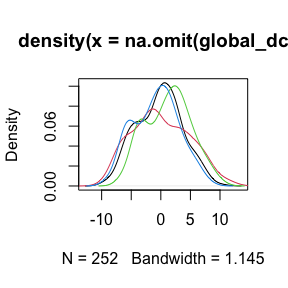

```r
plot(density(na.omit(global_dct)))
lines(density(na.omit(endogenous_dct)), col=2)
lines(density(na.omit(genorm_dct)), col=3)
lines(density(na.omit(normfinder_dct)), col=4)
```

## FAQS

### Some of my plates have differing numbers of detectors how should I proceed

```r
input_directory <- system.file('extdata', 'edsfiles', package='qPCRExperiment')
example_experiment <- readEDSExperiment(input_directory, directory=TRUE, verbose=FALSE)
print(sapply(example_experiment[['plates']], n_detectors))
```

```
##    /private/var/folders/pj/x9ry1wc12t780w6ql1c219kr0000gn/T/RtmpZiJdrF/temp_libpath1126420833904/qPCRExperiment/extdata/edsfiles/BPR14-13-01-19.eds
##                                                                                                                                                 554
## /private/var/folders/pj/x9ry1wc12t780w6ql1c219kr0000gn/T/RtmpZiJdrF/temp_libpath1126420833904/qPCRExperiment/extdata/edsfiles/newBXF34-28-01-19.eds
##                                                                                                                                                 754
```

```r
plates_to_keep <- plate_names(example_experiment)[sapply(example_experiment[['plates']], n_detectors) == 754]
example_experiment[,,plates_to_keep]
```

```
## EDS Experiment with:
##   1 Plates
##   3 Samples
##   754 Detectors
## History:
##             Submitted            Finished
## 1 2023-12-29 15:16:37 2023-12-29 15:17:00
## 2 2023-12-29 15:17:01 2023-12-29 15:17:01
##                                                        Comment
## 1 Create EDSExperiment with 2 plates, 6 samples, 754 detectors
## 2                 Subset to 1 plates, 3 samples, 754 detectors
```

or keep an intersection of the detectors present in all

```r
print(head(table(unlist(sapply(example_experiment[['plates']], detector_names)))))
```

```
##
##   ath-miR159a_478411_mir cel-miR-39-3p_478293_mir hsa-let-7a-3p_477861_mir
##                       84                       84                        6
## hsa-let-7a-5p_478575_mir hsa-let-7b-3p_478221_mir hsa-let-7b-5p_478576_mir
##                        6                        3                        6
```

```r
shared_detectors <- names(which(table(unlist(sapply(example_experiment[['plates']], detector_names))) == 6))
example_experiment[shared_detectors,,]
```

```
## EDS Experiment with:
##   2 Plates
##   6 Samples
##   551 Detectors
## History:
##             Submitted            Finished
## 1 2023-12-29 15:16:37 2023-12-29 15:17:00
## 2 2023-12-29 15:17:01 2023-12-29 15:17:01
##                                                        Comment
## 1 Create EDSExperiment with 2 plates, 6 samples, 754 detectors
## 2                 Subset to 2 plates, 6 samples, 551 detectors
```